# Graduate Employment and Salary Analysis in Singapore (2021–2023)

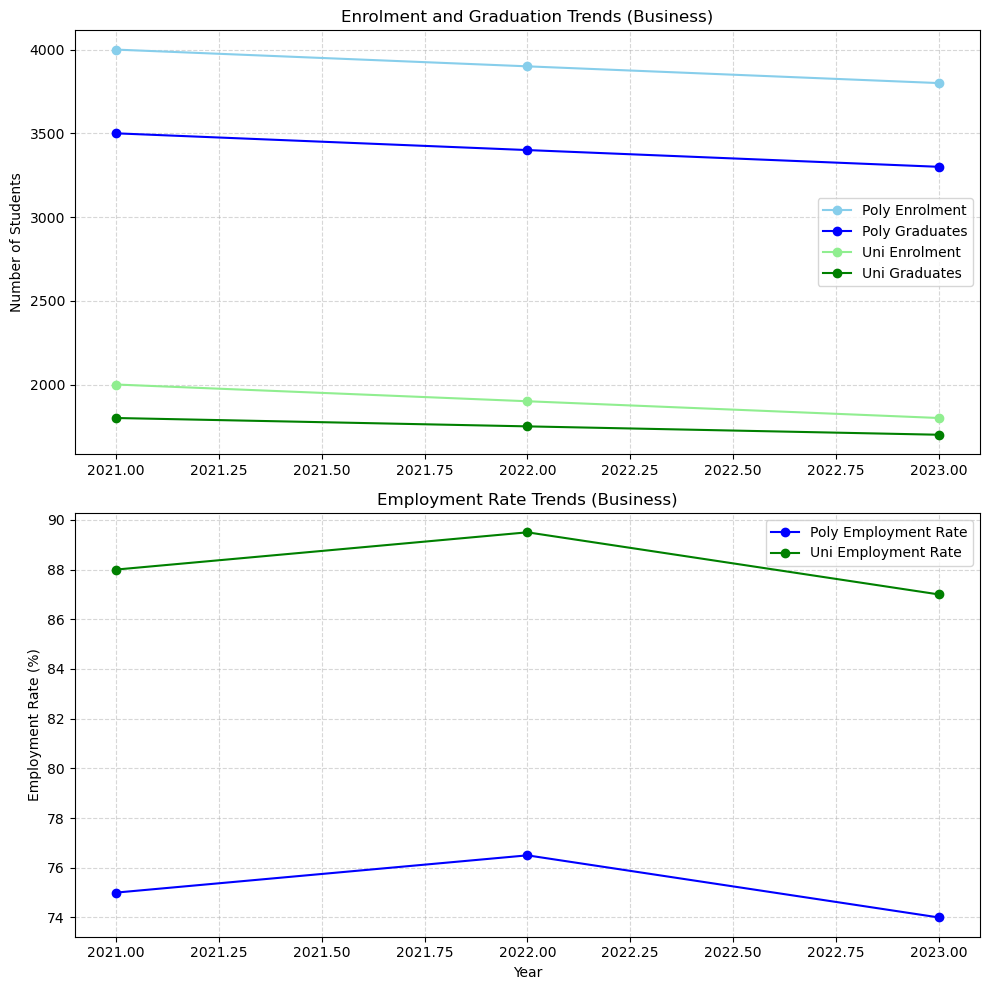

```python
import numpy as np
import matplotlib.pyplot as plt

# Years
years = np.array([2021, 2022, 2023])

# Example data for "Business"
poly_enrolment = np.array([4000, 3900, 3800])
poly_graduates = np.array([3500, 3400, 3300])
poly_employment_rate = np.array([75.0, 76.5, 74.0])

uni_enrolment = np.array([2000, 1900, 1800])
uni_graduates = np.array([1800, 1750, 1700])
uni_employment_rate = np.array([88.0, 89.5, 87.0])

# Plot
fig, axs = plt.subplots(2, 1, figsize=(10, 10))

# Enrolment & Graduates
axs[0].plot(years, poly_enrolment, marker='o', label='Poly Enrolment', color='skyblue')
axs[0].plot(years, poly_graduates, marker='o', label='Poly Graduates', color='blue')
axs[0].plot(years, uni_enrolment, marker='o', label='Uni Enrolment', color='lightgreen')
axs[0].plot(years, uni_graduates, marker='o', label='Uni Graduates', color='green')
axs[0].set_title('Enrolment and Graduation Trends (Business)')
axs[0].set_ylabel('Number of Students')
axs[0].legend()
axs[0].grid(True, linestyle='--', alpha=0.5)

# Employment Rates
axs[1].plot(years, poly_employment_rate, marker='o', label='Poly Employment Rate', color='blue')
axs[1].plot(years, uni_employment_rate, marker='o', label='Uni Employment Rate', color='green')
axs[1].set_title('Employment Rate Trends (Business)')
axs[1].set_ylabel('Employment Rate (%)')
axs[1].set_xlabel('Year')
axs[1].legend()
axs[1].grid(True, linestyle='--', alpha=0.5)

plt.tight_layout()
plt.savefig('trends_by_course.png')
plt.show()
```

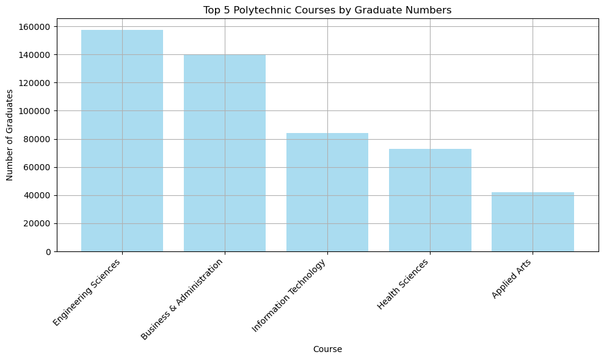

```python
import csv
import matplotlib.pyplot as plt

# Function to read CSV
def read_csv(filename):
    data = []
    try:
        with open(filename, mode='r', encoding='utf-8-sig') as file:
            reader = csv.DictReader(file)
            for row in reader:
                data.append(row)
    except FileNotFoundError:
        print(f"File not found: {filename}")
    return data

# Read datasets
poly_data = read_csv('IntakeEnrolmentandGraduatesofPolytechnicsbyCourse.csv')

# Aggregate graduate numbers by course
poly_grads = {}

for row in poly_data:
    course = row['course']
    graduates = row['graduates'].strip()
    try:
        graduates = int(graduates) if graduates else 0
    except:
        graduates = 0

    poly_grads[course] = poly_grads.get(course, 0) + graduates

# Get top 5 courses by graduate numbers
top_poly = sorted(poly_grads.items(), key=lambda x: x[1], reverse=True)[:5]

# Plotting
plt.figure(figsize=(10,6))

# Polytechnics
courses_poly = [x[0] for x in top_poly]
grads_poly = [x[1] for x in top_poly]
plt.bar(courses_poly, grads_poly, alpha=0.7, color='skyblue')

plt.title('Top 5 Polytechnic Courses by Graduate Numbers')
plt.xlabel('Course')
plt.ylabel('Number of Graduates')
plt.xticks(rotation=45, ha='right')
plt.tight_layout()
plt.grid(True)
plt.show()
```

## Final Conclusion

This comprehensive analysis of graduate employment data in Singapore from 2021 to 2023 provides critical insights for students, educators, and policymakers.

In summary, the findings show Singapore’s education system is aligned with labor market demands but highlight areas for continued improvement, such as enhancing polytechnic employability and guiding students toward in-demand fields.

## Data Sources

The following datasets were used in this analysis:

- [Graduate Employment Survey (GES) – Universities](https://data.gov.sg/dataset/graduate-employment-survey)
- [Polytechnic Graduate Employment Survey](https://data.gov.sg/dataset/polytechnic-graduate-employment-survey)
- [Full-Time Permanent Employment – Post-NS & Fresh](https://data.gov.sg/dataset/polytechnic-graduate-employment-survey)
- [Course-Level Graduate Outcomes](https://data.gov.sg/dataset/graduate-employment-survey)
- [Employment Rates of Polytechnic Graduates](https://www.tp.edu.sg/about-tp/media-centre/press-release/Employment-Rates-of-Polytechnic-Graduates-Remain-High-in-2023.html)